# title: “titanic_dataset_project”

# author: “Manuel Herrera Lara y Anahí Berumen Murillo”

# date: “15/9/2020”

# output: pdf_document

# The data domain

Usaremos Machine Learning para crear un modelo que predice cuáles pasajeros sobrevivieron al naufragio del titanic y/o qué tipo de personas tenían mas probabilidades de sobrevivir, usando información de los pasajeros que viajaban en el titanic; como su nombre, edad, sexo, clase socioeconómica, etc. Como breve descripción podemos decir que el hundimiento del titanic fue uno de los naufragios mas infames y recordados de la historia. El RMS Titanic fue un crucero de pasajeros británico que se hundió en el Océano Atlántico Norte y esto sucedió el 15 de abril de 1912, durante su viaje inaugural; y el RMS Titanic, considerado “insumergible”, se hundió tras chocar con un iceberg. Desafortunadamente, no había suficientes botes salvavidas para todos a bordo, lo que resultó en la muerte de 1502 de los 2224 pasajeros y la tripulación. Al parecer algunos grupos de personas tenían más probabilidades de sobrevivir que otros. Y por último destacamos que el Titanic era el barco más grande a flote en el momento y fue construido por el astillero Harland and Wolff en Belfast.

# Describe each of the variables

## >> Variable, definición y/o posibles valores

**PassengerId**

Número de identificación del pasajero.

**Survived**

Indica si el pasajero sobrevivió. 0 = No, 1 = Yes.

**Pclass**

**Name**

Nombre del pasajero.

**Sex**

Género del pasajero. Masculino y/o Femenino.

**Age**

Edad del pasajero.

**SibSp**

Número de hermanos y/o cónyuges a bordo.

**Parch**

Número de padres y/o niños a bordo.

**Ticket**

Número de boleto del pasajero.

**Fare**

Tarifa de pasajero.

**Cabin**

Número de cabina del pasajero.

**Embarked**

Puerto de embarcación. (C = Cherbourg; Q = Queenstown; S = Southampton).

## Notas adicionales para algunas variables

**pclass**

Indica el status o clase socioeconómica del pasajero.

2 = Media

**sibsp**

El dataset define las relaciones familiares de esta forma:

sibling = hermano, hermana, hermanastro, hermanastra.

spouse = esposo y/o esposa.

**parch**

El dataset define las relaciones familiares de esta forma:

parent: mamá o papá.

child: hijo, hija, hermanastro y/o hermanastra.

```r
knitr::opts_chunk$set(echo = TRUE)
# path of the dataset
setwd("/home/chino/Documentos/17_materias_IS/1_mineria_de_datos/4_semana_miniproyecto1/1_titanic_dataset_project_es")

# read the dataset
titanic <- read.csv("titanic.csv", stringsAsFactors = FALSE)
```

# Basic summary statics

- mostramos los primeros 10 registros del dataset

```r
head(titanic, 10)
```

```
##    PassengerId Survived Pclass
## 1            1        0      3
## 2            2        1      1
## 3            3        1      3
## 4            4        1      1
## 5            5        0      3
## 6            6        0      3
## 7            7        0      1
## 8            8        0      3
## 9            9        1      3
## 10          10        1      2
##                                                   Name    Sex Age SibSp Parch
## 1                              Braund, Mr. Owen Harris   male  22     1     0
## 2  Cumings, Mrs. John Bradley (Florence Briggs Thayer) female  38     1     0
## 3                               Heikkinen, Miss. Laina female  26     0     0
```

[output cut: 18 more lines]

- mostramos la estructura de los datos y/o los tipos de datos de los atributos

```r
str(titanic)
```

```
## 'data.frame':    891 obs. of  12 variables:
##  $ PassengerId: int  1 2 3 4 5 6 7 8 9 10 ...
##  $ Survived   : int  0 1 1 1 0 0 0 0 1 1 ...
##  $ Pclass     : int  3 1 3 1 3 3 1 3 3 2 ...
##  $ Name       : chr  "Braund, Mr. Owen Harris" "Cumings, Mrs. John Bradley (Florence Briggs Thayer)" "Heikkinen, Miss. Laina" "Futrelle, Mrs. Jacques Heath (Lily May Peel)" ...
##  $ Sex        : chr  "male" "female" "female" "female" ...
##  $ Age        : num  22 38 26 35 35 NA 54 2 27 14 ...
##  $ SibSp      : int  1 1 0 1 0 0 0 3 0 1 ...
##  $ Parch      : int  0 0 0 0 0 0 0 1 2 0 ...
##  $ Ticket     : chr  "A/5 21171" "PC 17599" "STON/O2. 3101282" "113803" ...
##  $ Fare       : num  7.25 71.28 7.92 53.1 8.05 ...
##  $ Cabin      : chr  "" "C85" "" "C123" ...
##  $ Embarked   : chr  "S" "C" "S" "S" ...
```

- resumen con las medidas estadisticas básicas

```r
summary(titanic)
```

```
##   PassengerId       Survived          Pclass          Name
##  Min.   :  1.0   Min.   :0.0000   Min.   :1.000   Length:891
##  1st Qu.:223.5   1st Qu.:0.0000   1st Qu.:2.000   Class :character
##  Median :446.0   Median :0.0000   Median :3.000   Mode  :character
##  Mean   :446.0   Mean   :0.3838   Mean   :2.309
##  3rd Qu.:668.5   3rd Qu.:1.0000   3rd Qu.:3.000
##  Max.   :891.0   Max.   :1.0000   Max.   :3.000
##
##      Sex                 Age            SibSp           Parch
##  Length:891         Min.   : 0.42   Min.   :0.000   Min.   :0.0000
##  Class :character   1st Qu.:20.12   1st Qu.:0.000   1st Qu.:0.0000
##  Mode  :character   Median :28.00   Median :0.000   Median :0.0000
##                     Mean   :29.70   Mean   :0.523   Mean   :0.3816
##                     3rd Qu.:38.00   3rd Qu.:1.000   3rd Qu.:0.0000
##                     Max.   :80.00   Max.   :8.000   Max.   :6.0000
##                     NA's   :177
##     Ticket               Fare           Cabin             Embarked
##  Length:891         Min.   :  0.00   Length:891         Length:891
##  Class :character   1st Qu.:  7.91   Class :character   Class :character
##  Mode  :character   Median : 14.45   Mode  :character   Mode  :character
##                     Mean   : 32.20
##                     3rd Qu.: 31.00
##                     Max.   :512.33
##
```

## Exploring the Categorical Variables

#### >> Gender Grouping

```r
table(titanic$Sex)
```

```
##
## female   male
##    314    577
```

#### Showing Percentages

```r
sex_table <- table(titanic$Sex)
sex_pct <- prop.table(sex_table) * 100
round(sex_pct, digits = 1)
```

```
##
## female   male
##   35.2   64.8
```

#### >> Embarked

```r
table(titanic$Embarked)
```

```
##
##       C   Q   S
##   2 168  77 644
```

#### Showing Percentages

```r
embarked_table <- table(titanic$Embarked)
embarked_pct <- prop.table(embarked_table) * 100
round(embarked_pct, digits = 1)
```

```
##
##         C    Q    S
##  0.2 18.9  8.6 72.3
```

#### >> PClass

```r
table(titanic$Pclass)
```

```
##
##   1   2   3
## 216 184 491
```

#### Showing Percentages

```r
pclass_table <- table(titanic$Pclass)
pclass_pct <- prop.table(pclass_table) * 100
round(pclass_pct, digits = 1)
```

```
##
##    1    2    3
## 24.2 20.7 55.1
```

#### >> Survived

```r
table(titanic$Survived)
```

```
##
##   0   1
## 549 342
```

#### Showing Percentages

```r
survived_table <- table(titanic$Survived)
survived_pct <- prop.table(survived_table) * 100
round(survived_pct, digits = 1)
```

```
##
##    0    1
## 61.6 38.4
```

# Boxplots - Interpretation

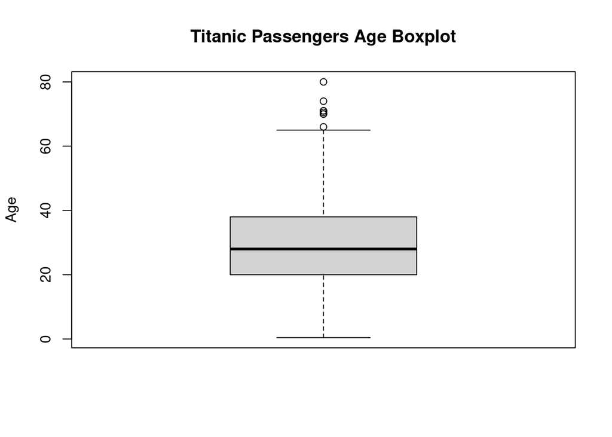

```r
boxplot(titanic$Age, main = "Titanic Passengers Age Boxplot", ylab ="Age")
```

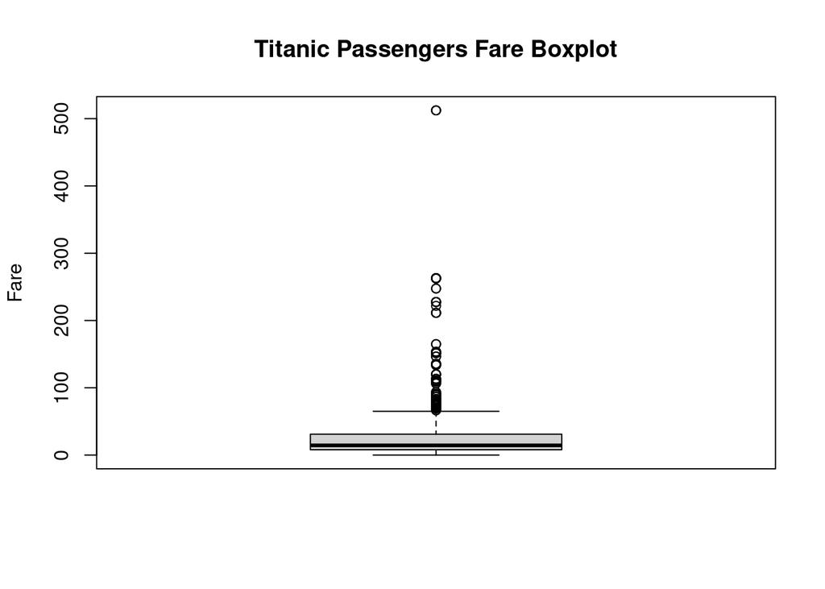

```r
boxplot(titanic$Fare, main = "Titanic Passengers Fare Boxplot", ylab = "Fare")
```

# Histograms-Interpretation and Skew of the data-Interpretation.

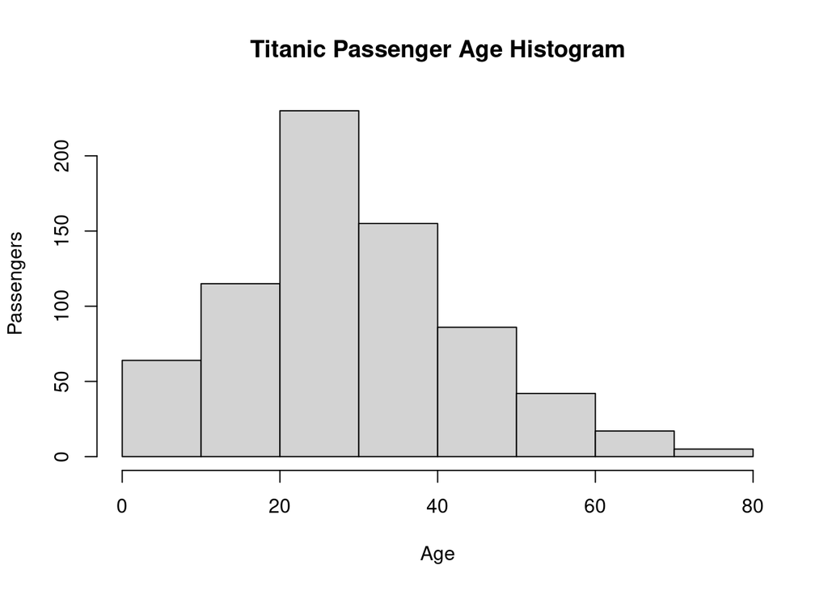

```r
hist(titanic$Age, main = "Titanic Passenger Age Histogram", xlab = "Age", ylab = "Passengers")
```

Observamos que la mayoría de los pasajeros pagó un costo menor a 100 dolares en sus boletos de abordar. Y es una distribución **no simétrica** ya que esta sesgada hacia la derecha porque la tárifa promedio es mayor a la tárifa media.

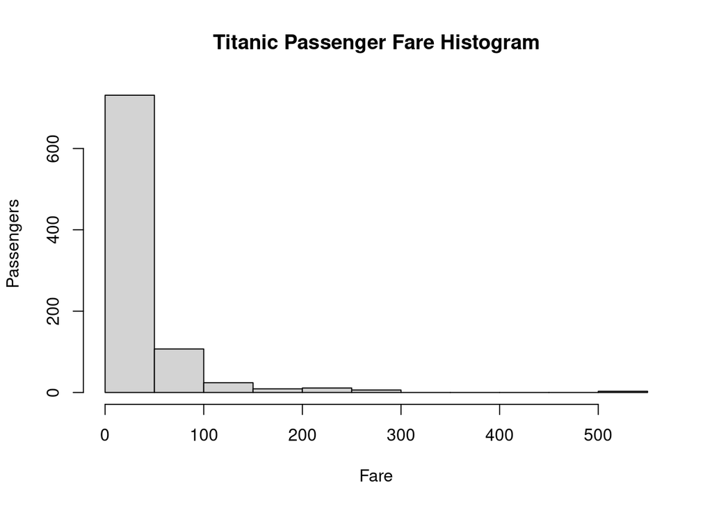

```r
hist(titanic$Fare, main = "Titanic Passenger Fare Histogram", xlab = "Fare", ylab = "Passengers")
```

Observamos que la mayoría de los pasajeros que viajaban en el titanic murió y menos de la mitad sobrevivio. Mostrando las cifras 549 pasajeros murieron y 342 sobrevivieron.

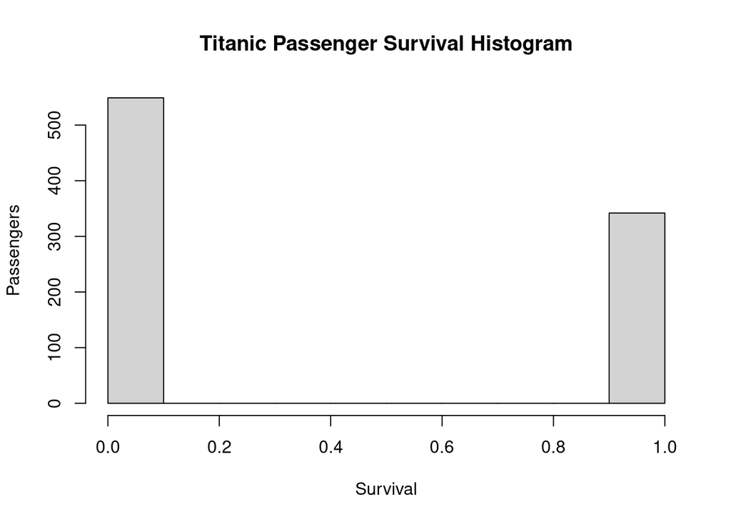

```r
hist(titanic$Survived, main = "Titanic Passenger Survival Histogram", xlab = "Survival", ylab = "Passengers")
```

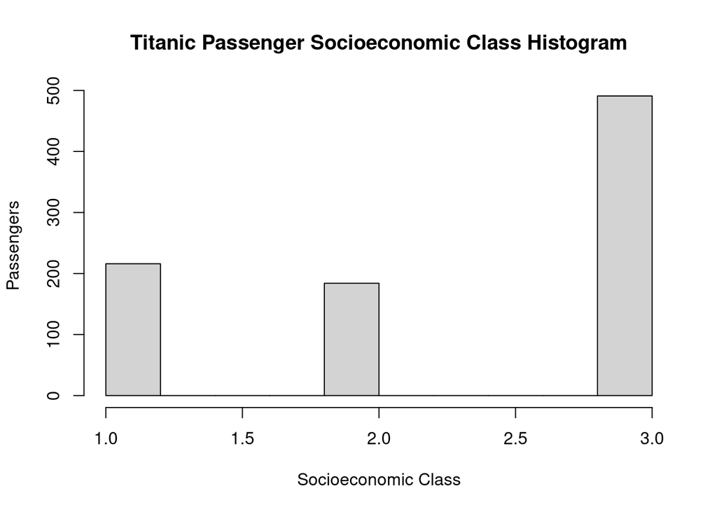

```r
hist(titanic$Pclass, main = "Titanic Passenger Socioeconomic Class Histogram", xlab = "Socioeconomic Class", ylab = "Passengers")
```